# Indel Signature InsDel16

# InsDel16

**Note**

The spectrum of the tumor WES::TCGA-13-0889-01A-01W-0420-08 is taken as signature InsDel16.

In the 89-type classification, InsDel16 and InsDel11 have a cosine similarity of 0.965, but as extracted from the 476-type classification, InsDel11 differs obviously from InsDel16, with insertion of single Cs next to isolated Cs (Cs with non-Cs on each side) and insertion of single Ts next to isolated Ts.

By contrast, InsDel_C has insertions of Cs between non-Cs and Gs, and insertion of Ts between non-Ts.

(corresponds to 83-type signature C_ID16 )

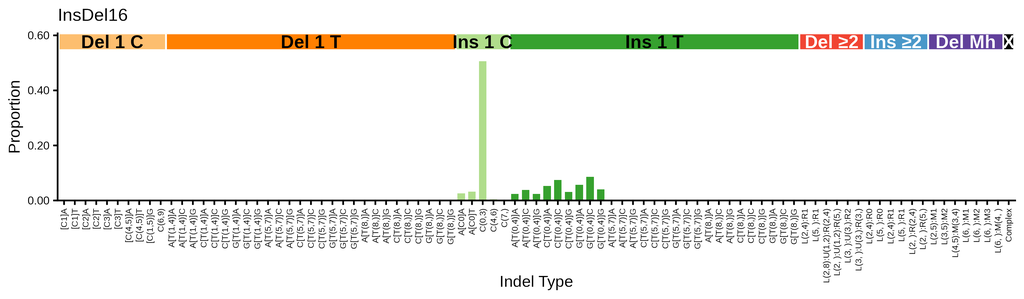

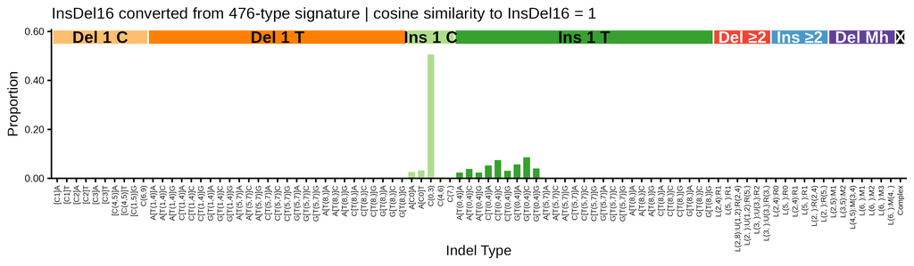

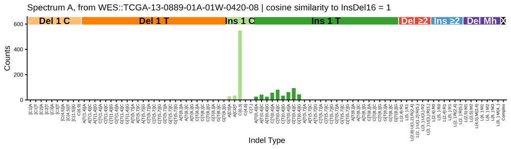

## 476-type representations corresponding to InsDel16

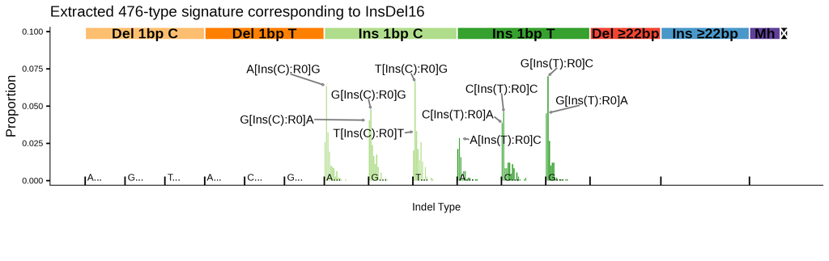

476-type spectrum of the supporting tumor WES::TCGA-13-0889-01A-01W-0420-08; cosine similarity to the extracted 476-type signature is 1

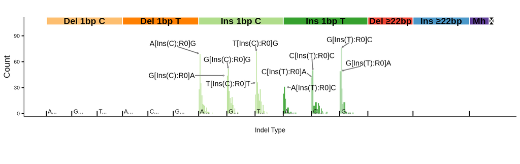

## 83-type signature corresponding to InsDel16 ( C_ID16 )

**Click here to show 83-type plots**

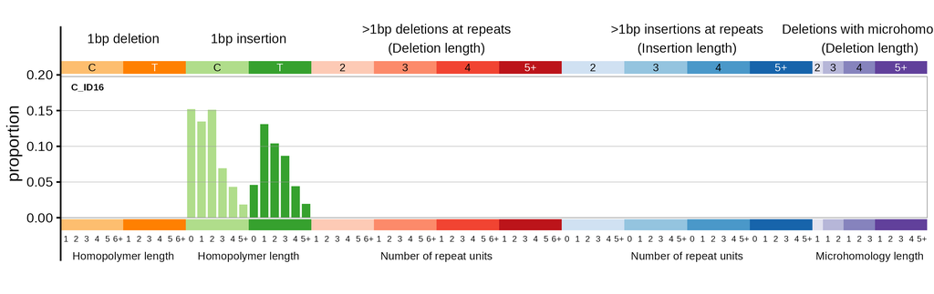

83-type signature converted from 476-type signature corresponding to InsDel16 | cosine similarity to C_ID16: 0.6727

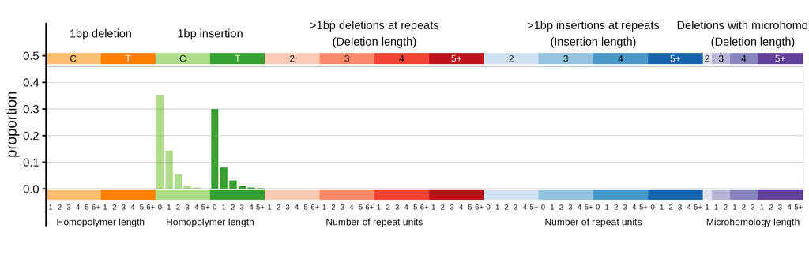

83-type spectrum of the supporting tumor WES::TCGA-13-0889-01A-01W-0420-08 | cosine similarly to C_ID16: 1

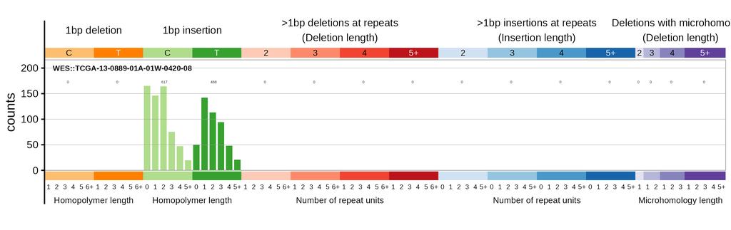

### Similar COSMIC signatures

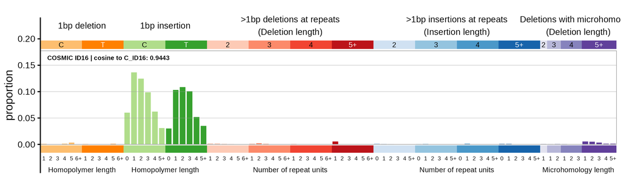